# Bank Customer Churn

```python
#import all the required library

import numpy as np
import pandas as pd
import matplotlib.pyplot as plt
import seaborn as sns
from sklearn.preprocessing import LabelEncoder, StandardScaler
from sklearn.model_selection import train_test_split
from sklearn.linear_model import LogisticRegression
from sklearn.svm import SVC
from sklearn.ensemble import RandomForestClassifier
from sklearn.model_selection import cross_val_score
from sklearn.model_selection import KFold

import warnings
warnings.filterwarnings('ignore')
```

```python
df = pd.read_csv('Churn_Modelling.csv')

df.head()
```

|  | RowNumber | CustomerId | Surname | CreditScore | Geography | Gender | Age | Tenure | Balance | NumOfProducts | HasCrCard | IsActiveMember | EstimatedSalary | Exited |
| --- | --- | --- | --- | --- | --- | --- | --- | --- | --- | --- | --- | --- | --- | --- |
| 0 | 1 | 15634602 | Hargrave | 619 | France | Female | 42 | 2 | 0.00 | 1 | 1 | 1 | 101348.88 | 1 |
| 1 | 2 | 15647311 | Hill | 608 | Spain | Female | 41 | 1 | 83807.86 | 1 | 0 | 1 | 112542.58 | 0 |
| 2 | 3 | 15619304 | Onio | 502 | France | Female | 42 | 8 | 159660.80 | 3 | 1 | 0 | 113931.57 | 1 |
| 3 | 4 | 15701354 | Boni | 699 | France | Female | 39 | 1 | 0.00 | 2 | 0 | 0 | 93826.63 | 0 |
| 4 | 5 | 15737888 | Mitchell | 850 | Spain | Female | 43 | 2 | 125510.82 | 1 | 1 | 1 | 79084.10 | 0 |

```python
#To display the number of rows and columns
df.shape
```

```
(10000, 14)
```

```python
#To display the column names
df.columns
```

```
Index(['RowNumber', 'CustomerId', 'Surname', 'CreditScore', 'Geography',
       'Gender', 'Age', 'Tenure', 'Balance', 'NumOfProducts', 'HasCrCard',
       'IsActiveMember', 'EstimatedSalary', 'Exited'],
      dtype='object')
```

```python
#To display the number of rows not null and the data type
df.info()
```

```
<class 'pandas.core.frame.DataFrame'>
RangeIndex: 10000 entries, 0 to 9999
Data columns (total 14 columns):
 #   Column           Non-Null Count  Dtype
---  ------           --------------  -----
 0   RowNumber        10000 non-null  int64
 1   CustomerId       10000 non-null  int64
 2   Surname          10000 non-null  object
 3   CreditScore      10000 non-null  int64
 4   Geography        10000 non-null  object
 5   Gender           10000 non-null  object
 6   Age              10000 non-null  int64
 7   Tenure           10000 non-null  int64
 8   Balance          10000 non-null  float64
 9   NumOfProducts    10000 non-null  int64
 10  HasCrCard        10000 non-null  int64
 11  IsActiveMember   10000 non-null  int64
 12  EstimatedSalary  10000 non-null  float64
 13  Exited           10000 non-null  int64
dtypes: float64(2), int64(9), object(3)
memory usage: 1.1+ MB
```

```python
#Displays the data type
df.dtypes
```

```
RowNumber            int64
CustomerId           int64
Surname             object
CreditScore          int64
Geography           object
Gender              object
Age                  int64
Tenure               int64
Balance            float64
NumOfProducts        int64
HasCrCard            int64
IsActiveMember       int64
EstimatedSalary    float64
Exited               int64
dtype: object
```

```python
#To display the total number of missing values present in the dataset
df.isna().sum()
```

```
RowNumber          0
CustomerId         0
Surname            0
CreditScore        0
Geography          0
Gender             0
Age                0
Tenure             0
Balance            0
NumOfProducts      0
HasCrCard          0
IsActiveMember     0
EstimatedSalary    0
Exited             0
dtype: int64
```

```python
#OR
df.isnull().sum()
```

```
RowNumber          0
CustomerId         0
Surname            0
CreditScore        0
Geography          0
Gender             0
Age                0
Tenure             0
Balance            0
NumOfProducts      0
HasCrCard          0
IsActiveMember     0
EstimatedSalary    0
Exited             0
dtype: int64
```

```python
#To check for duplicated data
df.duplicated().sum()
```

```
0
```

```python
#To remove columns not needed for the analysis (ensure to save it in a new variable name)
data = df.drop(columns=['RowNumber', 'CustomerId', 'Surname'], axis=1)

data
```

|  | CreditScore | Geography | Gender | Age | Tenure | Balance | NumOfProducts | HasCrCard | IsActiveMember | EstimatedSalary | Exited |
| --- | --- | --- | --- | --- | --- | --- | --- | --- | --- | --- | --- |
| 0 | 619 | France | Female | 42 | 2 | 0.00 | 1 | 1 | 1 | 101348.88 | 1 |
| 1 | 608 | Spain | Female | 41 | 1 | 83807.86 | 1 | 0 | 1 | 112542.58 | 0 |
| 2 | 502 | France | Female | 42 | 8 | 159660.80 | 3 | 1 | 0 | 113931.57 | 1 |
| 3 | 699 | France | Female | 39 | 1 | 0.00 | 2 | 0 | 0 | 93826.63 | 0 |
| 4 | 850 | Spain | Female | 43 | 2 | 125510.82 | 1 | 1 | 1 | 79084.10 | 0 |
| ... | ... | ... | ... | ... | ... | ... | ... | ... | ... | ... | ... |
| 9995 | 771 | France | Male | 39 | 5 | 0.00 | 2 | 1 | 0 | 96270.64 | 0 |
| 9996 | 516 | France | Male | 35 | 10 | 57369.61 | 1 | 1 | 1 | 101699.77 | 0 |
| 9997 | 709 | France | Female | 36 | 7 | 0.00 | 1 | 0 | 1 | 42085.58 | 1 |
| 9998 | 772 | Germany | Male | 42 | 3 | 75075.31 | 2 | 1 | 0 | 92888.52 | 1 |
| 9999 | 792 | France | Female | 28 | 4 | 130142.79 | 1 | 1 | 0 | 38190.78 | 0 |

10000 rows × 11 columns

# Descriptive statistics for numerical columns

```python
#To display the mean, std, min & max
data.describe()
```

|  | CreditScore | Age | Tenure | Balance | NumOfProducts | HasCrCard | IsActiveMember | EstimatedSalary | Exited |
| --- | --- | --- | --- | --- | --- | --- | --- | --- | --- |
| count | 10000.000000 | 10000.000000 | 10000.000000 | 10000.000000 | 10000.000000 | 10000.00000 | 10000.000000 | 10000.000000 | 10000.000000 |
| mean | 650.528800 | 38.921800 | 5.012800 | 76485.889288 | 1.530200 | 0.70550 | 0.515100 | 100090.239881 | 0.203700 |
| std | 96.653299 | 10.487806 | 2.892174 | 62397.405202 | 0.581654 | 0.45584 | 0.499797 | 57510.492818 | 0.402769 |
| min | 350.000000 | 18.000000 | 0.000000 | 0.000000 | 1.000000 | 0.00000 | 0.000000 | 11.580000 | 0.000000 |
| 25% | 584.000000 | 32.000000 | 3.000000 | 0.000000 | 1.000000 | 0.00000 | 0.000000 | 51002.110000 | 0.000000 |
| 50% | 652.000000 | 37.000000 | 5.000000 | 97198.540000 | 1.000000 | 1.00000 | 1.000000 | 100193.915000 | 0.000000 |
| 75% | 718.000000 | 44.000000 | 7.000000 | 127644.240000 | 2.000000 | 1.00000 | 1.000000 | 149388.247500 | 0.000000 |
| max | 850.000000 | 92.000000 | 10.000000 | 250898.090000 | 4.000000 | 1.00000 | 1.000000 | 199992.480000 | 1.000000 |

# Descriptive statistics for object dtype columns

```python
data.describe(include=[object])
```

|  | Geography | Gender |
| --- | --- | --- |
| count | 10000 | 10000 |
| unique | 3 | 2 |
| top | France | Male |
| freq | 5014 | 5457 |

```python
#To display the unique values
data['Geography'].unique()
```

```
array(['France', 'Spain', 'Germany'], dtype=object)
```

```python
data['Gender'].unique()
```

```
array(['Female', 'Male'], dtype=object)
```

# Univariate Analysis on numerical variable

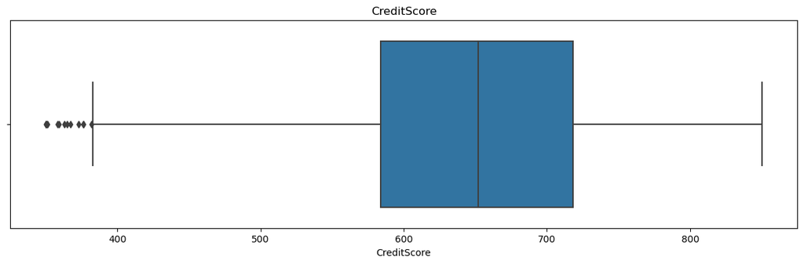

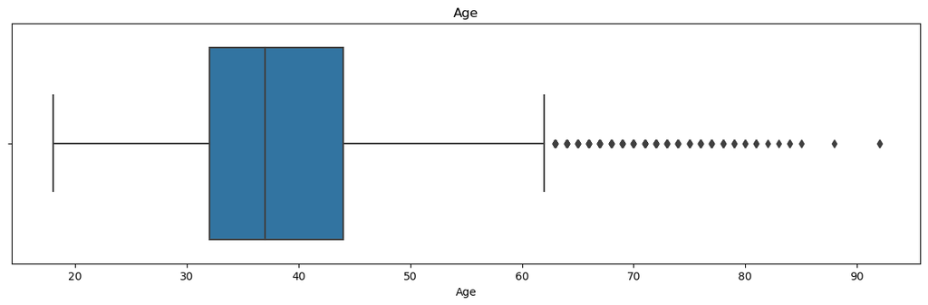

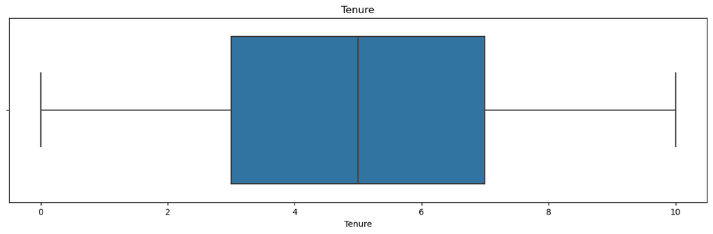

```python
for column in ['CreditScore', 'Age', 'Tenure']:
    plt.figure(figsize=(15, 4))
    sns.boxplot(data=data, x=column)
    plt.title(column)
    plt.show()
```

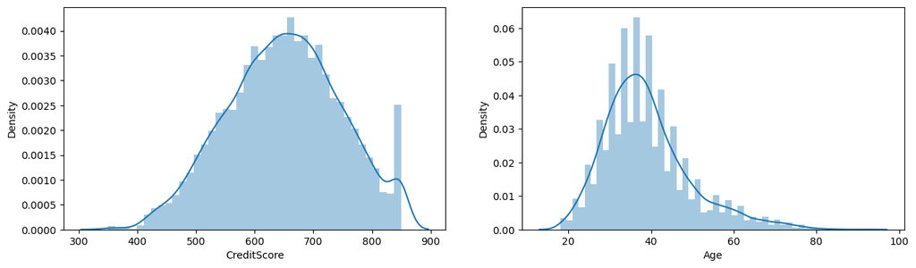

```python
#To combine 2 plots in a single plot(e.g creditscore & age)
plt.figure(figsize=(15,4))

plt.subplot(1,2,1)
sns.distplot(data['CreditScore'])

plt.subplot(1,2,2)
sns.distplot(data['Age'])
```

# Univariate analysis on categorical columns

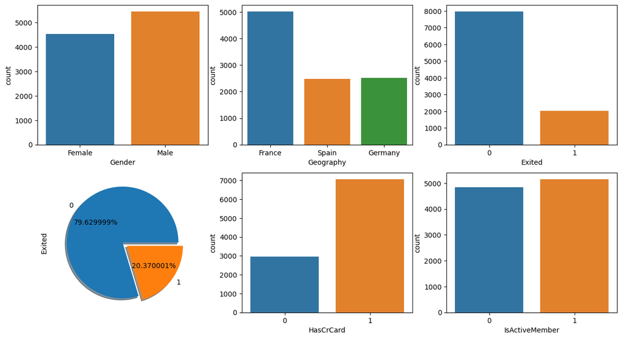

```python
plt.figure(figsize=(15, 8))

plt.subplot(2,3,1)
sns.countplot(data['Gender'])

plt.subplot(2,3,2)
sns.countplot(data['Geography'])

plt.subplot(2,3,3)
sns.countplot(data['Exited'])

plt.subplot(2,3,4)
data['Exited'].value_counts().plot(kind='pie', explode=[0, 0.1], autopct = lambda p:f'{p:2f}%',
                                   labels=['0', '1'], shadow=True, pctdistance=0.6)

plt.subplot(2,3,5)
sns.countplot(data['HasCrCard'])

plt.subplot(2,3,6)
sns.countplot(data['IsActiveMember'])
```

```python
#To display counts
data['Geography'].value_counts()
```

```
France     5014
Germany    2509
Spain      2477
Name: Geography, dtype: int64
```

```python
data['Gender'].value_counts()
```

```
Male      5457
Female    4543
Name: Gender, dtype: int64
```

```python
data['Exited'].value_counts()
```

```
0    7963
1    2037
Name: Exited, dtype: int64
```

# Bivariate analysis

```python
#To display the impact of gender on the exit rate (0=NO, 1=YES)
print('Impact of Gender on Churn rate')
print(pd.crosstab(data['Gender'], data['Exited']))
```

```
Impact of Gender on Churn rate
Exited     0     1
Gender
Female  3404  1139
Male    4559   898
```

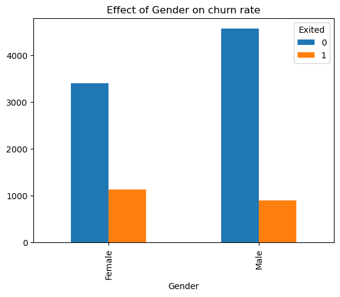

```python
plt.figure(figsize=(10, 3))
x = pd.crosstab(data['Gender'], data['Exited'])
x.plot.bar()
plt.title('Effect of Gender on churn rate', fontsize = 12)
```

# Multivariate Analysis

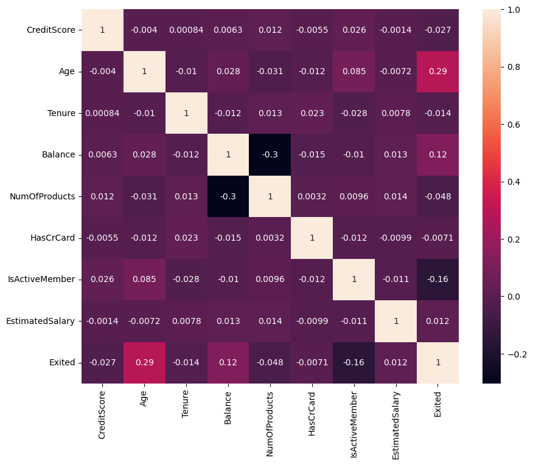

```python
#Multivariate analysis
#Lets check the heatmap for the data with respect to correlation
#Heatmap returns only columns with integers and float

plt.figure(figsize=(10, 8))
sns.heatmap(data.corr(), annot=True)
```

# Data Preprocessing

```python
data.head()
```

[output not shown]

```python
from sklearn.preprocessing import LabelEncoder

le = LabelEncoder()
data['Geography'] = le.fit_transform(data['Geography'])
data['Gender'] = le.fit_transform(data['Gender'])
```

```python
data
```

|  | CreditScore | Geography | Gender | Age | Tenure | Balance | NumOfProducts | HasCrCard | IsActiveMember | EstimatedSalary | Exited |
| --- | --- | --- | --- | --- | --- | --- | --- | --- | --- | --- | --- |
| 0 | 619 | 0 | 0 | 42 | 2 | 0.00 | 1 | 1 | 1 | 101348.88 | 1 |
| 1 | 608 | 2 | 0 | 41 | 1 | 83807.86 | 1 | 0 | 1 | 112542.58 | 0 |
| 2 | 502 | 0 | 0 | 42 | 8 | 159660.80 | 3 | 1 | 0 | 113931.57 | 1 |
| 3 | 699 | 0 | 0 | 39 | 1 | 0.00 | 2 | 0 | 0 | 93826.63 | 0 |
| 4 | 850 | 2 | 0 | 43 | 2 | 125510.82 | 1 | 1 | 1 | 79084.10 | 0 |
| ... | ... | ... | ... | ... | ... | ... | ... | ... | ... | ... | ... |
| 9995 | 771 | 0 | 1 | 39 | 5 | 0.00 | 2 | 1 | 0 | 96270.64 | 0 |
| 9996 | 516 | 0 | 1 | 35 | 10 | 57369.61 | 1 | 1 | 1 | 101699.77 | 0 |
| 9997 | 709 | 0 | 0 | 36 | 7 | 0.00 | 1 | 0 | 1 | 42085.58 | 1 |
| 9998 | 772 | 1 | 1 | 42 | 3 | 75075.31 | 2 | 1 | 0 | 92888.52 | 1 |
| 9999 | 792 | 0 | 0 | 28 | 4 | 130142.79 | 1 | 1 | 0 | 38190.78 | 0 |

10000 rows × 11 columns

```python
data.dtypes
```

```
CreditScore          int64
Geography            int32
Gender               int32
Age                  int64
Tenure               int64
Balance            float64
NumOfProducts        int64
HasCrCard            int64
IsActiveMember       int64
EstimatedSalary    float64
Exited               int64
dtype: object
```

```python
data['Geography'].value_counts()
```

```
0    5014
1    2509
2    2477
Name: Geography, dtype: int64
```

```python
data['Gender'].value_counts()
```

```
1    5457
0    4543
Name: Gender, dtype: int64
```

Splitting the dataset into y(dependent variables) and x(independent variable)

```python
X = data.drop('Exited', axis=1)
y = data['Exited']
```

```python
#Now X does not contain the exited column since it has been dropped
X
```

|  | CreditScore | Geography | Gender | Age | Tenure | Balance | NumOfProducts | HasCrCard | IsActiveMember | EstimatedSalary |
| --- | --- | --- | --- | --- | --- | --- | --- | --- | --- | --- |
| 0 | 619 | 0 | 0 | 42 | 2 | 0.00 | 1 | 1 | 1 | 101348.88 |
| 1 | 608 | 2 | 0 | 41 | 1 | 83807.86 | 1 | 0 | 1 | 112542.58 |
| 2 | 502 | 0 | 0 | 42 | 8 | 159660.80 | 3 | 1 | 0 | 113931.57 |
| 3 | 699 | 0 | 0 | 39 | 1 | 0.00 | 2 | 0 | 0 | 93826.63 |
| 4 | 850 | 2 | 0 | 43 | 2 | 125510.82 | 1 | 1 | 1 | 79084.10 |
| ... | ... | ... | ... | ... | ... | ... | ... | ... | ... | ... |
| 9995 | 771 | 0 | 1 | 39 | 5 | 0.00 | 2 | 1 | 0 | 96270.64 |
| 9996 | 516 | 0 | 1 | 35 | 10 | 57369.61 | 1 | 1 | 1 | 101699.77 |
| 9997 | 709 | 0 | 0 | 36 | 7 | 0.00 | 1 | 0 | 1 | 42085.58 |
| 9998 | 772 | 1 | 1 | 42 | 3 | 75075.31 | 2 | 1 | 0 | 92888.52 |
| 9999 | 792 | 0 | 0 | 28 | 4 | 130142.79 | 1 | 1 | 0 | 38190.78 |

10000 rows × 10 columns

```python
# Exited is here since its the dependent variable.
y
```

```
0       1
1       0
2       1
3       0
4       0
       ..
9995    0
9996    0
9997    1
9998    1
9999    0
Name: Exited, Length: 10000, dtype: int64
```

```python
#Splitting the dataset into training and test

from sklearn.model_selection import train_test_split

X_train, X_test, y_train, y_test = train_test_split(X, y, test_size=0.2, random_state=0)
```

```python
X_train
```

|  | CreditScore | Geography | Gender | Age | Tenure | Balance | NumOfProducts | HasCrCard | IsActiveMember | EstimatedSalary |
| --- | --- | --- | --- | --- | --- | --- | --- | --- | --- | --- |
| 7389 | 667 | 2 | 0 | 34 | 5 | 0.00 | 2 | 1 | 0 | 163830.64 |
| 9275 | 427 | 1 | 1 | 42 | 1 | 75681.52 | 1 | 1 | 1 | 57098.00 |
| 2995 | 535 | 0 | 0 | 29 | 2 | 112367.34 | 1 | 1 | 0 | 185630.76 |
| 5316 | 654 | 2 | 1 | 40 | 5 | 105683.63 | 1 | 1 | 0 | 173617.09 |
| 356 | 850 | 2 | 0 | 57 | 8 | 126776.30 | 2 | 1 | 1 | 132298.49 |
| ... | ... | ... | ... | ... | ... | ... | ... | ... | ... | ... |
| 9225 | 594 | 1 | 0 | 32 | 4 | 120074.97 | 2 | 1 | 1 | 162961.79 |
| 4859 | 794 | 2 | 0 | 22 | 4 | 114440.24 | 1 | 1 | 1 | 107753.07 |
| 3264 | 738 | 0 | 1 | 35 | 5 | 161274.05 | 2 | 1 | 0 | 181429.87 |
| 9845 | 590 | 2 | 0 | 38 | 9 | 0.00 | 2 | 1 | 1 | 148750.16 |
| 2732 | 623 | 1 | 0 | 48 | 1 | 108076.33 | 1 | 1 | 0 | 118855.26 |

8000 rows × 10 columns

```python
y_train
```

```
7389    0
9275    0
2995    0
5316    0
356     0
       ..
9225    0
4859    0
3264    0
9845    0
2732    1
Name: Exited, Length: 8000, dtype: int64
```

```python
X_test
```

|  | CreditScore | Geography | Gender | Age | Tenure | Balance | NumOfProducts | HasCrCard | IsActiveMember | EstimatedSalary |
| --- | --- | --- | --- | --- | --- | --- | --- | --- | --- | --- |
| 9394 | 597 | 1 | 0 | 35 | 8 | 131101.04 | 1 | 1 | 1 | 192852.67 |
| 898 | 523 | 0 | 0 | 40 | 2 | 102967.41 | 1 | 1 | 0 | 128702.10 |
| 2398 | 706 | 2 | 0 | 42 | 8 | 95386.82 | 1 | 1 | 1 | 75732.25 |
| 5906 | 788 | 0 | 1 | 32 | 4 | 112079.58 | 1 | 0 | 0 | 89368.59 |
| 2343 | 706 | 1 | 1 | 38 | 5 | 163034.82 | 2 | 1 | 1 | 135662.17 |
| ... | ... | ... | ... | ... | ... | ... | ... | ... | ... | ... |
| 1037 | 625 | 0 | 0 | 24 | 1 | 0.00 | 2 | 1 | 1 | 180969.55 |
| 2899 | 586 | 0 | 0 | 35 | 7 | 0.00 | 2 | 1 | 0 | 70760.69 |
| 9549 | 578 | 2 | 1 | 36 | 1 | 157267.95 | 2 | 1 | 0 | 141533.19 |
| 2740 | 650 | 1 | 1 | 34 | 4 | 142393.11 | 1 | 1 | 1 | 11276.48 |
| 6690 | 573 | 1 | 1 | 30 | 8 | 127406.50 | 1 | 1 | 0 | 192950.60 |

2000 rows × 10 columns

```python
y_test
```

```
9394    0
898     1
2398    0
5906    0
2343    0
       ..
1037    0
2899    0
9549    0
2740    0
6690    0
Name: Exited, Length: 2000, dtype: int64
```

```python
from sklearn.model_selection import train_test_split

X_train, X_test, y_train, y_test = train_test_split(X, y, test_size=0.2, random_state=0)

print('shape of the X_train:', X_train.shape)
print('shape of the X_test:', X_test.shape)
print('shape of the y_train:', y_train.shape)
print('shape of the y_test:', y_test.shape)
```

```
shape of the X_train: (8000, 10)
shape of the X_test: (2000, 10)
shape of the y_train: (8000,)
shape of the y_test: (2000,)
```

Always scale only the independent variable

```python
from sklearn.preprocessing import StandardScaler

ss = StandardScaler()
X_train = ss.fit_transform(X_train)
X_test = ss.fit_transform(X_test)
```

```python
X_train
```

```
array([[ 0.16958176,  1.51919821, -1.09168714, ...,  0.64259497,
        -1.03227043,  1.10643166],
       [-2.30455945,  0.3131264 ,  0.91601335, ...,  0.64259497,
         0.9687384 , -0.74866447],
       [-1.19119591, -0.89294542, -1.09168714, ...,  0.64259497,
        -1.03227043,  1.48533467],
       ...,
       [ 0.9015152 , -0.89294542,  0.91601335, ...,  0.64259497,
        -1.03227043,  1.41231994],
       [-0.62420521,  1.51919821, -1.09168714, ...,  0.64259497,
         0.9687384 ,  0.84432121],
       [-0.28401079,  0.3131264 , -1.09168714, ...,  0.64259497,
        -1.03227043,  0.32472465]])
```

```python
#Return it to a dataframe
X_train = pd.DataFrame(X_train)
```

```python
X_train
```

|  | 0 | 1 | 2 | 3 | 4 | 5 | 6 | 7 | 8 | 9 |
| --- | --- | --- | --- | --- | --- | --- | --- | --- | --- | --- |
| 0 | 0.169582 | 1.519198 | -1.091687 | -0.464608 | 0.006661 | -1.215717 | 0.809503 | 0.642595 | -1.032270 | 1.106432 |
| 1 | -2.304559 | 0.313126 | 0.916013 | 0.301026 | -1.377440 | -0.006312 | -0.921591 | 0.642595 | 0.968738 | -0.748664 |
| 2 | -1.191196 | -0.892945 | -1.091687 | -0.943129 | -1.031415 | 0.579935 | -0.921591 | 0.642595 | -1.032270 | 1.485335 |
| 3 | 0.035566 | 1.519198 | 0.916013 | 0.109617 | 0.006661 | 0.473128 | -0.921591 | 0.642595 | -1.032270 | 1.276528 |
| 4 | 2.056114 | 1.519198 | -1.091687 | 1.736588 | 1.044737 | 0.810193 | 0.809503 | 0.642595 | 0.968738 | 0.558378 |
| ... | ... | ... | ... | ... | ... | ... | ... | ... | ... | ... |
| 7995 | -0.582970 | 0.313126 | -1.091687 | -0.656016 | -0.339364 | 0.703104 | 0.809503 | 0.642595 | 0.968738 | 1.091330 |
| 7996 | 1.478815 | 1.519198 | -1.091687 | -1.613058 | -0.339364 | 0.613060 | -0.921591 | 0.642595 | 0.968738 | 0.131760 |
| 7997 | 0.901515 | -0.892945 | 0.916013 | -0.368904 | 0.006661 | 1.361474 | 0.809503 | 0.642595 | -1.032270 | 1.412320 |
| 7998 | -0.624205 | 1.519198 | -1.091687 | -0.081791 | 1.390762 | -1.215717 | 0.809503 | 0.642595 | 0.968738 | 0.844321 |
| 7999 | -0.284011 | 0.313126 | -1.091687 | 0.875251 | -1.377440 | 0.511364 | -0.921591 | 0.642595 | -1.032270 | 0.324725 |

8000 rows × 10 columns

# Creating and Training Model

# Logistic Regression Model

```python
from sklearn.linear_model import LogisticRegression

log_model = LogisticRegression()
log_model.fit(X_train, y_train)
```

```
LogisticRegression()
```

```python
#To check the accuracy score
log_model.score(X_train, y_train)
```

```
0.8085
```

This gives us 81% accuracy, this shows us how our model is performing

# Decision Tree Classifier Model

```python
from sklearn.tree import DecisionTreeClassifier

tree_clf = DecisionTreeClassifier()
tree_clf.fit(X_train, y_train)
```

```
DecisionTreeClassifier()
```

```python
tree_clf.score(X_train, y_train)
```

```
1.0
```

This gives us 100% accuracy.

# Support Vector Machine Model

```python
from sklearn.svm import SVC

svc_model = SVC()
svc_model.fit(X_train, y_train)
```

```
SVC()
```

```python
svc_model.score(X_train, y_train)
```

```
0.862
```

This gives us 86% accuracy

# Random Forest Classifier Model

```python
from sklearn.ensemble import RandomForestClassifier

ensemble_rfc = RandomForestClassifier()
ensemble_rfc.fit(X_train, y_train)
```

```
RandomForestClassifier()
```

```python
ensemble_rfc.score(X_train, y_train)
```

```
1.0
```

This gives us 100% accuracy

Random forest and Decision tree perfectly fitted the data, could that be true? This is a signal that the model overfitted (i.e it memorized the training data but would likely be poor when tested on the new data). Overfitting is usually caused by using complex models and small data.

# Model Evaluation

Evaluating classification models is not as simple as for regression models. When you have skewed dataset or imbalances, you can get a high accuracy and you can think the model did well when in fact it didn't.

In this part, we are going to learn how to evaluate classification models, but first, let's evaluate the model with cross validation.

Here is an idea of cross validation, we want to divide the training set into different training and validation subsets so that we can literarily train and validate the models on those subsets.

Take an example, if we divide our training data into 10 subsets (commonly known as folds), each subset will take 10% of the whole data. As a result using cross validation, we will train 10 different modelswhere each model is trained on 9 different subsets and validated on 1 subset or fold. By the end of such process, we will have 10 different model scores.

```python
#Logistic Regression Evaluation
from sklearn.model_selection import cross_val_score
from sklearn.model_selection import KFold

kf = KFold(n_splits=10)
log_score = cross_val_score(log_model, X_train, y_train, cv=kf)
```

```python
log_score
```

```
array([0.7975 , 0.80125, 0.80375, 0.80375, 0.84   , 0.8175 , 0.805  ,
       0.8075 , 0.8025 , 0.81   ])
```

```python
log_score.mean()
```

```
0.8088750000000001
```

```python
#Decision Tree Classifier Evaluation
from sklearn.model_selection import cross_val_score
from sklearn.model_selection import KFold

kf = KFold(n_splits=10)
tree_score = cross_val_score(tree_clf, X_train, y_train, cv=kf)
```

```python
tree_score
```

```
array([0.80625, 0.7725 , 0.795  , 0.75   , 0.81875, 0.7775 , 0.81375,
       0.77125, 0.77875, 0.77625])
```

```python
tree_score.mean()
```

```
0.786
```

```python
#Support Vector Machine Evaluation
from sklearn.model_selection import cross_val_score
from sklearn.model_selection import KFold

kf = KFold(n_splits=10)
svc_model = cross_val_score(svc_model, X_train, y_train, cv=kf)
```

```python
svc_model
```

```
array([0.85875, 0.85375, 0.865  , 0.84625, 0.87   , 0.85375, 0.8525 ,
       0.84375, 0.8375 , 0.8525 ])
```

```python
svc_model.mean()
```

```
0.8533750000000001
```

```python
#Random Forest Evaluation
from sklearn.model_selection import cross_val_score
from sklearn.model_selection import KFold

kf = KFold(n_splits=10)
ensemble_rfc = cross_val_score(ensemble_rfc, X_train, y_train, cv=kf)
```

```python
ensemble_rfc
```

```
array([0.86625, 0.85875, 0.8725 , 0.85125, 0.8625 , 0.86625, 0.85625,
       0.85375, 0.85125, 0.87   ])
```

```python
ensemble_rfc
```